# House Prices Prediction

The aim of this project is to build a model to predict the housing prices in Boston using the Boston Housing dataset which has 79 features some of which are: Overall material and finish quality, The building class, Above grade (ground) living area square feet etc.

The data was acquired from [Kaggle](https://www.kaggle.com/c/house-prices-advanced-regression-techniques/overview).

The GitHub repository for this project can be found [here](https://github.com/nicksento/House-Prices-Prediction).

It is a typical supervised learning task since we are given labeled training examples (each instance comes with the expected output).

It is also a typical regression task, since we are asked to predict a value (the Sale Price).

Finally, there is no continuous flow of data coming in the system, there is no particular need to adjust to changing data rapidly, and the data is small enough to fit in memory, so plain batch learning should do just fine.

# Import Libraries

```python
import pandas as pd
import numpy as np

import matplotlib.pyplot as plt
import seaborn as sns
%matplotlib inline

from sklearn.model_selection import train_test_split
from sklearn.impute import SimpleImputer
from sklearn.impute import KNNImputer
from sklearn.preprocessing import OrdinalEncoder
from sklearn.preprocessing import OneHotEncoder

from sklearn.pipeline import Pipeline
from sklearn.preprocessing import StandardScaler
from sklearn.compose import ColumnTransformer

from sklearn.linear_model import LinearRegression
```

# Import Data

We are going to read and take a look at our data

```python
df = pd.read_csv('data/train.csv')
```

```python
df.head()
```

|  | Id | MSSubClass | MSZoning | LotFrontage | LotArea | Street | Alley | LotShape | LandContour | Utilities | ... | PoolArea | PoolQC | Fence | MiscFeature | MiscVal | MoSold | YrSold | SaleType | SaleCondition | SalePrice |
| --- | --- | --- | --- | --- | --- | --- | --- | --- | --- | --- | --- | --- | --- | --- | --- | --- | --- | --- | --- | --- | --- |
| 0 | 1 | 60 | RL | 65.0 | 8450 | Pave | NaN | Reg | Lvl | AllPub | ... | 0 | NaN | NaN | NaN | 0 | 2 | 2008 | WD | Normal | 208500 |
| 1 | 2 | 20 | RL | 80.0 | 9600 | Pave | NaN | Reg | Lvl | AllPub | ... | 0 | NaN | NaN | NaN | 0 | 5 | 2007 | WD | Normal | 181500 |
| 2 | 3 | 60 | RL | 68.0 | 11250 | Pave | NaN | IR1 | Lvl | AllPub | ... | 0 | NaN | NaN | NaN | 0 | 9 | 2008 | WD | Normal | 223500 |
| 3 | 4 | 70 | RL | 60.0 | 9550 | Pave | NaN | IR1 | Lvl | AllPub | ... | 0 | NaN | NaN | NaN | 0 | 2 | 2006 | WD | Abnorml | 140000 |
| 4 | 5 | 60 | RL | 84.0 | 14260 | Pave | NaN | IR1 | Lvl | AllPub | ... | 0 | NaN | NaN | NaN | 0 | 12 | 2008 | WD | Normal | 250000 |

5 rows × 81 columns

```python
df.columns
```

```
Index(['Id', 'MSSubClass', 'MSZoning', 'LotFrontage', 'LotArea', 'Street',
       'Alley', 'LotShape', 'LandContour', 'Utilities', 'LotConfig',
       'LandSlope', 'Neighborhood', 'Condition1', 'Condition2', 'BldgType',
       'HouseStyle', 'OverallQual', 'OverallCond', 'YearBuilt', 'YearRemodAdd',
       'RoofStyle', 'RoofMatl', 'Exterior1st', 'Exterior2nd', 'MasVnrType',
       'MasVnrArea', 'ExterQual', 'ExterCond', 'Foundation', 'BsmtQual',
       'BsmtCond', 'BsmtExposure', 'BsmtFinType1', 'BsmtFinSF1',
       'BsmtFinType2', 'BsmtFinSF2', 'BsmtUnfSF', 'TotalBsmtSF', 'Heating',
       'HeatingQC', 'CentralAir', 'Electrical', '1stFlrSF', '2ndFlrSF',
       'LowQualFinSF', 'GrLivArea', 'BsmtFullBath', 'BsmtHalfBath', 'FullBath',
       'HalfBath', 'BedroomAbvGr', 'KitchenAbvGr', 'KitchenQual',
       'TotRmsAbvGrd', 'Functional', 'Fireplaces', 'FireplaceQu', 'GarageType',
       'GarageYrBlt', 'GarageFinish', 'GarageCars', 'GarageArea', 'GarageQual',
       'GarageCond', 'PavedDrive', 'WoodDeckSF', 'OpenPorchSF',
       'EnclosedPorch', '3SsnPorch', 'ScreenPorch', 'PoolArea', 'PoolQC',
       'Fence', 'MiscFeature', 'MiscVal', 'MoSold', 'YrSold', 'SaleType',
       'SaleCondition', 'SalePrice'],
      dtype='object')
```

```python
df.shape
```

```
(1460, 81)
```

1460 instances and 81 features. Fairly small by Machine Learning standards. We have a mix of numerical, categorical and ordinal features.

```python
df.info()
```

```
<class 'pandas.core.frame.DataFrame'>
RangeIndex: 1460 entries, 0 to 1459
Data columns (total 81 columns):
 #   Column         Non-Null Count  Dtype
---  ------         --------------  -----
 0   Id             1460 non-null   int64
 1   MSSubClass     1460 non-null   int64
 2   MSZoning       1460 non-null   object
 3   LotFrontage    1201 non-null   float64
 4   LotArea        1460 non-null   int64
 5   Street         1460 non-null   object
 6   Alley          91 non-null     object
 7   LotShape       1460 non-null   object
 8   LandContour    1460 non-null   object
 9   Utilities      1460 non-null   object
```

[output cut: 73 more lines]

```python
df.describe()
```

|  | Id | MSSubClass | LotFrontage | LotArea | OverallQual | OverallCond | YearBuilt | YearRemodAdd | MasVnrArea | BsmtFinSF1 | ... | WoodDeckSF | OpenPorchSF | EnclosedPorch | 3SsnPorch | ScreenPorch | PoolArea | MiscVal | MoSold | YrSold | SalePrice |
| --- | --- | --- | --- | --- | --- | --- | --- | --- | --- | --- | --- | --- | --- | --- | --- | --- | --- | --- | --- | --- | --- |
| count | 1460.000000 | 1460.000000 | 1201.000000 | 1460.000000 | 1460.000000 | 1460.000000 | 1460.000000 | 1460.000000 | 1452.000000 | 1460.000000 | ... | 1460.000000 | 1460.000000 | 1460.000000 | 1460.000000 | 1460.000000 | 1460.000000 | 1460.000000 | 1460.000000 | 1460.000000 | 1460.000000 |
| mean | 730.500000 | 56.897260 | 70.049958 | 10516.828082 | 6.099315 | 5.575342 | 1971.267808 | 1984.865753 | 103.685262 | 443.639726 | ... | 94.244521 | 46.660274 | 21.954110 | 3.409589 | 15.060959 | 2.758904 | 43.489041 | 6.321918 | 2007.815753 | 180921.195890 |
| std | 421.610009 | 42.300571 | 24.284752 | 9981.264932 | 1.382997 | 1.112799 | 30.202904 | 20.645407 | 181.066207 | 456.098091 | ... | 125.338794 | 66.256028 | 61.119149 | 29.317331 | 55.757415 | 40.177307 | 496.123024 | 2.703626 | 1.328095 | 79442.502883 |
| min | 1.000000 | 20.000000 | 21.000000 | 1300.000000 | 1.000000 | 1.000000 | 1872.000000 | 1950.000000 | 0.000000 | 0.000000 | ... | 0.000000 | 0.000000 | 0.000000 | 0.000000 | 0.000000 | 0.000000 | 0.000000 | 1.000000 | 2006.000000 | 34900.000000 |
| 25% | 365.750000 | 20.000000 | 59.000000 | 7553.500000 | 5.000000 | 5.000000 | 1954.000000 | 1967.000000 | 0.000000 | 0.000000 | ... | 0.000000 | 0.000000 | 0.000000 | 0.000000 | 0.000000 | 0.000000 | 0.000000 | 5.000000 | 2007.000000 | 129975.000000 |
| 50% | 730.500000 | 50.000000 | 69.000000 | 9478.500000 | 6.000000 | 5.000000 | 1973.000000 | 1994.000000 | 0.000000 | 383.500000 | ... | 0.000000 | 25.000000 | 0.000000 | 0.000000 | 0.000000 | 0.000000 | 0.000000 | 6.000000 | 2008.000000 | 163000.000000 |
| 75% | 1095.250000 | 70.000000 | 80.000000 | 11601.500000 | 7.000000 | 6.000000 | 2000.000000 | 2004.000000 | 166.000000 | 712.250000 | ... | 168.000000 | 68.000000 | 0.000000 | 0.000000 | 0.000000 | 0.000000 | 0.000000 | 8.000000 | 2009.000000 | 214000.000000 |
| max | 1460.000000 | 190.000000 | 313.000000 | 215245.000000 | 10.000000 | 9.000000 | 2010.000000 | 2010.000000 | 1600.000000 | 5644.000000 | ... | 857.000000 | 547.000000 | 552.000000 | 508.000000 | 480.000000 | 738.000000 | 15500.000000 | 12.000000 | 2010.000000 | 755000.000000 |

8 rows × 38 columns

The count , mean , min , and max rows are self-explanatory. The std row shows the standard deviation, which measures how dispersed the values are. The 25%, 50%, and 75% rows show the corresponding percentiles: a percentile indicates the value below which a given percentage of observations in a group of observations falls.

# Visualize the Data

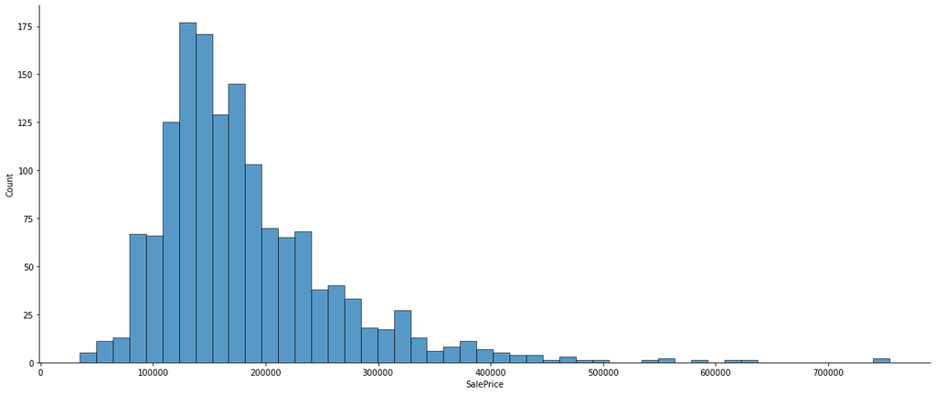

```python
g=sns.displot(df['SalePrice'])
g.fig.set_size_inches(18,7)
plt.show()
```

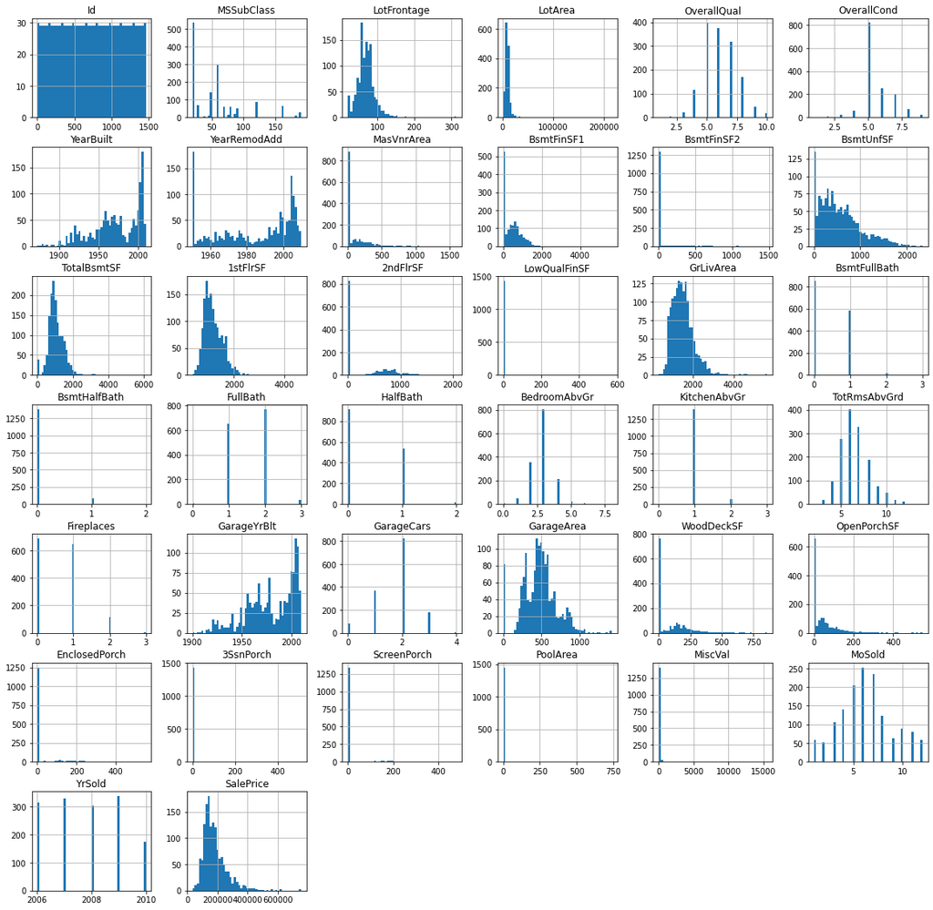

```python
df.hist(bins=50, figsize=(20,20))
plt.show()
```

# Create a test set

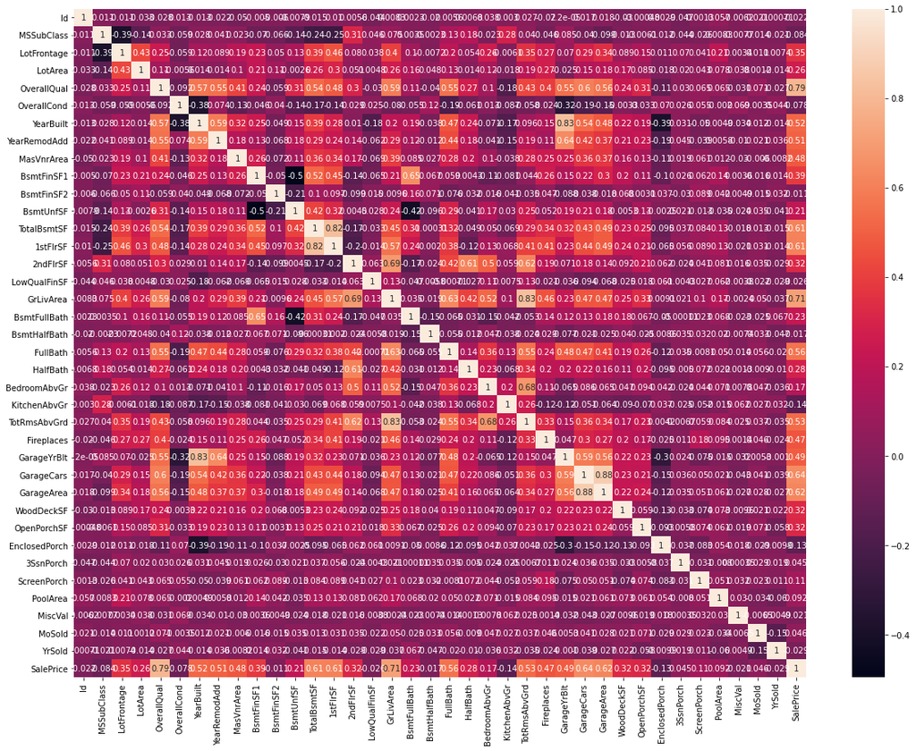

```python
corr = df.corr()
plt.figure(figsize=(20,15))
sns.heatmap(corr, annot=True)
plt.show()
```

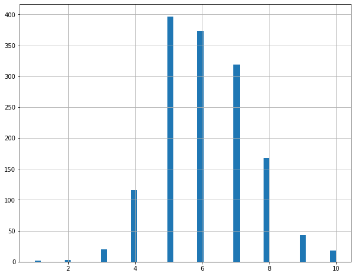

```python
df['OverallQual'].hist(bins=50, figsize=(10,8))
plt.show()
```

Next to the Stratified Sampling approach (i.e StratifiedShuffleSplit).Since it has been observed that the 'OverallQual' feature is important. We will want our test set to be representative of the various categories of OverallQual in the whole dataset. If we look at the histogram of the 'OverallQual' we created before, you will observe that that most of median income values are clustered around 5 to 8.

```python
df['OverallQual'].sort_values().unique()
```

```
array([ 1,  2,  3,  4,  5,  6,  7,  8,  9, 10])
```

```python
from sklearn.model_selection import StratifiedShuffleSplit

split = StratifiedShuffleSplit(n_splits=1, test_size=0.2, random_state=42)

for train_index, test_index in split.split(df, df['OverallQual']):
    strat_train_set = df.loc[train_index]
    strat_test_set = df.loc[test_index]
```

```python
def income_cat_proportions(data):
    return data["OverallQual"].value_counts() / len(data)

train_set, test_set = train_test_split(df, test_size=0.2, random_state=42)

compare_props = pd.DataFrame({
    "Overall": income_cat_proportions(df),
    "Stratified": income_cat_proportions(strat_test_set),
    "Random": income_cat_proportions(test_set),
}).sort_index()
compare_props["Rand. %error"] = 100 * compare_props["Random"] / compare_props["Overall"] - 100
compare_props["Strat. %error"] = 100 * compare_props["Stratified"] / compare_props["Overall"] - 100
```

```python
compare_props
```

|  | Overall | Stratified | Random | Rand. %error | Strat. %error |
| --- | --- | --- | --- | --- | --- |
| 1 | 0.001370 | NaN | NaN | NaN | NaN |
| 2 | 0.002055 | 0.003425 | 0.006849 | 233.333333 | 66.666667 |
| 3 | 0.013699 | 0.013699 | 0.013699 | 0.000000 | 0.000000 |
| 4 | 0.079452 | 0.078767 | 0.095890 | 20.689655 | -0.862069 |
| 5 | 0.271918 | 0.270548 | 0.304795 | 12.090680 | -0.503778 |
| 6 | 0.256164 | 0.256849 | 0.215753 | -15.775401 | 0.267380 |
| 7 | 0.218493 | 0.219178 | 0.208904 | -4.388715 | 0.313480 |
| 8 | 0.115068 | 0.113014 | 0.113014 | -1.785714 | -1.785714 |
| 9 | 0.029452 | 0.030822 | 0.023973 | -18.604651 | 4.651163 |
| 10 | 0.012329 | 0.013699 | 0.017123 | 38.888889 | 11.111111 |

```python
train = strat_train_set.copy()
test = strat_test_set.copy()
```

# Looking for Correlations

```python
corr_matrix = df.corr()
```

```python
corr_matrix['SalePrice'].sort_values(ascending=False)
```

```
SalePrice        1.000000
OverallQual      0.790982
GrLivArea        0.708624
GarageCars       0.640409
GarageArea       0.623431
TotalBsmtSF      0.613581
1stFlrSF         0.605852
FullBath         0.560664
TotRmsAbvGrd     0.533723
YearBuilt        0.522897
YearRemodAdd     0.507101
GarageYrBlt      0.486362
MasVnrArea       0.477493
Fireplaces       0.466929
BsmtFinSF1       0.386420
LotFrontage      0.351799
WoodDeckSF       0.324413
2ndFlrSF         0.319334
OpenPorchSF      0.315856
HalfBath         0.284108
LotArea          0.263843
BsmtFullBath     0.227122
BsmtUnfSF        0.214479
BedroomAbvGr     0.168213
ScreenPorch      0.111447
PoolArea         0.092404
MoSold           0.046432
3SsnPorch        0.044584
BsmtFinSF2      -0.011378
BsmtHalfBath    -0.016844
MiscVal         -0.021190
Id              -0.021917
LowQualFinSF    -0.025606
YrSold          -0.028923
OverallCond     -0.077856
MSSubClass      -0.084284
EnclosedPorch   -0.128578
KitchenAbvGr    -0.135907
Name: SalePrice, dtype: float64
```

### Scatter

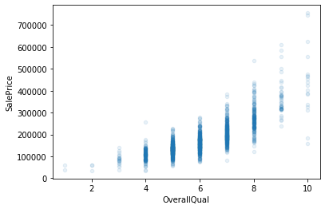

```python
df.plot(kind="scatter", x="OverallQual", y="SalePrice",
alpha=0.1)
```

# Prepare the Data for Machine Learning Algorithms

```python
X_train = strat_train_set.drop('SalePrice', axis=1)
y_train = strat_train_set.SalePrice.copy()
```

## NaN values

Most Machine Learning algorithms cannot work with missing features. To fix this we have three options:

- Get rid of the corresponding districts.
- Get rid of the whole attribute.
- Set the values to some value (zero, the mean, the median, etc.).

```python
train.isna().count()
```

```
Id               1168
MSSubClass       1168
MSZoning         1168
LotFrontage      1168
LotArea          1168
                 ...
MoSold           1168
YrSold           1168
SaleType         1168
SaleCondition    1168
SalePrice        1168
Length: 81, dtype: int64
```

```python
train.shape
```

```
(1168, 81)
```

```python
missing_values = train.isna().sum().sort_values(ascending=False) / len(train) * 100
missing_values[missing_values>0]
```

```
PoolQC          99.571918
MiscFeature     96.489726
Alley           94.006849
Fence           79.880137
FireplaceQu     46.318493
LotFrontage     17.636986
GarageCond       5.393836
GarageType       5.393836
GarageYrBlt      5.393836
GarageFinish     5.393836
GarageQual       5.393836
BsmtExposure     2.996575
BsmtFinType2     2.996575
BsmtFinType1     2.910959
BsmtCond         2.910959
BsmtQual         2.910959
MasVnrArea       0.684932
MasVnrType       0.684932
Electrical       0.085616
dtype: float64
```

```python
train = train.drop(['PoolQC', 'MiscFeature', 'Alley', 'Fence', 'FireplaceQu'], axis=1)
```

```python
missing_values = train.isna().sum().sort_values(ascending=False) / len(train) * 100
missing_values[missing_values>0]
```

```
LotFrontage     17.636986
GarageFinish     5.393836
GarageType       5.393836
GarageCond       5.393836
GarageQual       5.393836
GarageYrBlt      5.393836
BsmtExposure     2.996575
BsmtFinType2     2.996575
BsmtFinType1     2.910959
BsmtCond         2.910959
BsmtQual         2.910959
MasVnrType       0.684932
MasVnrArea       0.684932
Electrical       0.085616
dtype: float64
```

### Imputer = "median"

```python
imputer = SimpleImputer(strategy="median")
```

```python
# find numerical features
train_num = train.select_dtypes(include = [np.number])
train_num.shape
```

```
(1168, 38)
```

```python
train_num.head()
```

|  | Id | MSSubClass | LotFrontage | LotArea | OverallQual | OverallCond | YearBuilt | YearRemodAdd | MasVnrArea | BsmtFinSF1 | ... | WoodDeckSF | OpenPorchSF | EnclosedPorch | 3SsnPorch | ScreenPorch | PoolArea | MiscVal | MoSold | YrSold | SalePrice |
| --- | --- | --- | --- | --- | --- | --- | --- | --- | --- | --- | --- | --- | --- | --- | --- | --- | --- | --- | --- | --- | --- |
| 825 | 826 | 20 | 114.0 | 14803 | 10 | 5 | 2007 | 2008 | 816.0 | 1636 | ... | 188 | 45 | 0 | 0 | 0 | 0 | 0 | 6 | 2008 | 385000 |
| 948 | 949 | 60 | 65.0 | 14006 | 7 | 5 | 2002 | 2002 | 144.0 | 0 | ... | 144 | 96 | 0 | 0 | 0 | 0 | 0 | 2 | 2006 | 192500 |
| 188 | 189 | 90 | 64.0 | 7018 | 5 | 5 | 1979 | 1979 | 275.0 | 1086 | ... | 120 | 0 | 0 | 0 | 0 | 0 | 0 | 6 | 2009 | 153337 |
| 1059 | 1060 | 50 | NaN | 11275 | 6 | 7 | 1932 | 1950 | 480.0 | 297 | ... | 0 | 0 | 19 | 0 | 0 | 0 | 0 | 3 | 2007 | 220000 |
| 667 | 668 | 20 | 65.0 | 8125 | 6 | 5 | 1994 | 1998 | 258.0 | 1138 | ... | 224 | 42 | 0 | 0 | 0 | 0 | 0 | 10 | 2008 | 193500 |

5 rows × 38 columns

```python
imputer.fit(train_num)
```

```
SimpleImputer(strategy='median')
```

```python
imputer.statistics_
```

```
array([7.3950e+02, 5.0000e+01, 7.0000e+01, 9.5040e+03, 6.0000e+00,
       5.0000e+00, 1.9720e+03, 1.9930e+03, 0.0000e+00, 3.8200e+02,
       0.0000e+00, 4.6000e+02, 9.7700e+02, 1.0855e+03, 0.0000e+00,
       0.0000e+00, 1.4585e+03, 0.0000e+00, 0.0000e+00, 2.0000e+00,
       0.0000e+00, 3.0000e+00, 1.0000e+00, 6.0000e+00, 1.0000e+00,
       1.9790e+03, 2.0000e+00, 4.7600e+02, 0.0000e+00, 2.4000e+01,
       0.0000e+00, 0.0000e+00, 0.0000e+00, 0.0000e+00, 0.0000e+00,
       6.0000e+00, 2.0080e+03, 1.6300e+05])
```

```python
train_num.median().values
```

```
array([7.3950e+02, 5.0000e+01, 7.0000e+01, 9.5040e+03, 6.0000e+00,
       5.0000e+00, 1.9720e+03, 1.9930e+03, 0.0000e+00, 3.8200e+02,
       0.0000e+00, 4.6000e+02, 9.7700e+02, 1.0855e+03, 0.0000e+00,
       0.0000e+00, 1.4585e+03, 0.0000e+00, 0.0000e+00, 2.0000e+00,
       0.0000e+00, 3.0000e+00, 1.0000e+00, 6.0000e+00, 1.0000e+00,
       1.9790e+03, 2.0000e+00, 4.7600e+02, 0.0000e+00, 2.4000e+01,
       0.0000e+00, 0.0000e+00, 0.0000e+00, 0.0000e+00, 0.0000e+00,
       6.0000e+00, 2.0080e+03, 1.6300e+05])
```

```python
X = imputer.transform(train_num)
X
```

```
array([[8.26000e+02, 2.00000e+01, 1.14000e+02, ..., 6.00000e+00,
        2.00800e+03, 3.85000e+05],
       [9.49000e+02, 6.00000e+01, 6.50000e+01, ..., 2.00000e+00,
        2.00600e+03, 1.92500e+05],
       [1.89000e+02, 9.00000e+01, 6.40000e+01, ..., 6.00000e+00,
        2.00900e+03, 1.53337e+05],
       ...,
       [1.09100e+03, 9.00000e+01, 6.00000e+01, ..., 6.00000e+00,
        2.00900e+03, 9.29000e+04],
       [1.36900e+03, 1.20000e+02, 7.00000e+01, ..., 6.00000e+00,
        2.00900e+03, 1.44000e+05],
       [7.48000e+02, 7.00000e+01, 6.50000e+01, ..., 5.00000e+00,
        2.00900e+03, 2.65979e+05]])
```

```python
train_num_tr = pd.DataFrame(X, columns=train_num.columns)
```

## Handling Text and Categorical Attributes

## Impute missing values

```python
# find categorical features
train_cat = train.select_dtypes(exclude = [np.number])
train_cat.shape
```

```
(1168, 38)
```

```python
si_cat = SimpleImputer(strategy='most_frequent')
```

```python
train_cat_imputed = si_cat.fit_transform(train_cat)
```

```python
train_cat_imputed
```

```
array([['RL', 'Pave', 'Reg', ..., 'Y', 'New', 'Partial'],
       ['RL', 'Pave', 'IR1', ..., 'Y', 'WD', 'Normal'],
       ['RL', 'Pave', 'Reg', ..., 'Y', 'WD', 'Alloca'],
       ...,
       ['RL', 'Pave', 'Reg', ..., 'Y', 'WD', 'Normal'],
       ['RM', 'Pave', 'Reg', ..., 'Y', 'WD', 'Normal'],
       ['RM', 'Pave', 'IR1', ..., 'N', 'WD', 'Normal']], dtype=object)
```

```python
train_cat_imputed = pd.DataFrame(train_cat_imputed, columns=train_cat.columns)
train_cat_imputed.head()
```

|  | MSZoning | Street | LotShape | LandContour | Utilities | LotConfig | LandSlope | Neighborhood | Condition1 | Condition2 | ... | Electrical | KitchenQual | Functional | GarageType | GarageFinish | GarageQual | GarageCond | PavedDrive | SaleType | SaleCondition |
| --- | --- | --- | --- | --- | --- | --- | --- | --- | --- | --- | --- | --- | --- | --- | --- | --- | --- | --- | --- | --- | --- |
| 0 | RL | Pave | Reg | Lvl | AllPub | Inside | Gtl | NridgHt | PosN | PosN | ... | SBrkr | Ex | Typ | Attchd | Fin | TA | TA | Y | New | Partial |
| 1 | RL | Pave | IR1 | Lvl | AllPub | Inside | Gtl | CollgCr | Norm | Norm | ... | SBrkr | Gd | Typ | Attchd | RFn | TA | TA | Y | WD | Normal |
| 2 | RL | Pave | Reg | Bnk | AllPub | Inside | Gtl | SawyerW | Feedr | Norm | ... | SBrkr | TA | Typ | Detchd | Unf | TA | TA | Y | WD | Alloca |
| 3 | RL | Pave | IR1 | HLS | AllPub | Corner | Mod | Crawfor | Norm | Norm | ... | SBrkr | TA | Typ | Detchd | Unf | TA | Fa | Y | WD | Normal |
| 4 | RL | Pave | Reg | Lvl | AllPub | Inside | Gtl | SawyerW | Norm | Norm | ... | SBrkr | Gd | Typ | Attchd | RFn | TA | TA | Y | WD | Normal |

5 rows × 38 columns

## OneHotEncoder

```python
ohe = OneHotEncoder(sparse=False)
```

```python
train_cat_encoded = ohe.fit_transform(train_cat_imputed)
```

## Ordinal Encoder

```python
oe = OrdinalEncoder()
```

```python
train_cat_encoded = oe.fit_transform(train_cat_imputed)
```

```python
train_cat_encoded = pd.DataFrame(train_cat_encoded, columns=train_cat.columns)
train_cat_encoded.head()
```

|  | MSZoning | Street | LotShape | LandContour | Utilities | LotConfig | LandSlope | Neighborhood | Condition1 | Condition2 | ... | Electrical | KitchenQual | Functional | GarageType | GarageFinish | GarageQual | GarageCond | PavedDrive | SaleType | SaleCondition |
| --- | --- | --- | --- | --- | --- | --- | --- | --- | --- | --- | --- | --- | --- | --- | --- | --- | --- | --- | --- | --- | --- |
| 0 | 3.0 | 1.0 | 3.0 | 3.0 | 0.0 | 4.0 | 0.0 | 16.0 | 4.0 | 4.0 | ... | 4.0 | 0.0 | 5.0 | 1.0 | 0.0 | 4.0 | 4.0 | 2.0 | 6.0 | 5.0 |
| 1 | 3.0 | 1.0 | 0.0 | 3.0 | 0.0 | 4.0 | 0.0 | 5.0 | 2.0 | 2.0 | ... | 4.0 | 2.0 | 5.0 | 1.0 | 1.0 | 4.0 | 4.0 | 2.0 | 8.0 | 4.0 |
| 2 | 3.0 | 1.0 | 3.0 | 0.0 | 0.0 | 4.0 | 0.0 | 20.0 | 1.0 | 2.0 | ... | 4.0 | 3.0 | 5.0 | 5.0 | 2.0 | 4.0 | 4.0 | 2.0 | 8.0 | 2.0 |
| 3 | 3.0 | 1.0 | 0.0 | 1.0 | 0.0 | 0.0 | 1.0 | 6.0 | 2.0 | 2.0 | ... | 4.0 | 3.0 | 5.0 | 5.0 | 2.0 | 4.0 | 1.0 | 2.0 | 8.0 | 4.0 |
| 4 | 3.0 | 1.0 | 3.0 | 3.0 | 0.0 | 4.0 | 0.0 | 20.0 | 2.0 | 2.0 | ... | 4.0 | 2.0 | 5.0 | 1.0 | 1.0 | 4.0 | 4.0 | 2.0 | 8.0 | 4.0 |

5 rows × 38 columns

# Feature Scaling

There are two common ways to get all attributes to have the same scale: min-max scaling and standardization

Min-max scaling (many people call this normalization) is quite simple: values are shifted and rescaled so that they end up ranging from 0 to 1.

Standardization is quite different: first it subtracts the mean value (so standardized values always have a zero mean), and then it divides by the standard deviation so that the resulting distribution has unit variance. Unlike min-max scaling, standardization does not bound values to a specific range, which may be a problem for some algo‐ rithms (e.g., neural networks often expect an input value ranging from 0 to 1). How‐ ever, standardization is much less affected by outliers.

# Transformation Pipelines

```python
X_train.drop('Id', axis=1, inplace=True) # train set without id
```

```python
# find numerical and categorical features
train_num = X_train.select_dtypes(include = [np.number])
num_attribs = list(train_num)
train_cat = X_train.select_dtypes(exclude = [np.number])
cat_attribs = list(train_cat)
```

### Numeric pipeline

```python
num_pipeline = Pipeline([
    ('imputer', SimpleImputer(strategy="median")),
    #('attribs_adder', CombinedAttributesAdder()),
    ('std_scaler', StandardScaler()),
    ])
```

### Categorical pipeline

```python
cat_pipeline = Pipeline([
    ('imputer', SimpleImputer(strategy='most_frequent')),
    ('encoder', OneHotEncoder(handle_unknown='ignore')),
    ])
```

### Full pipeline

```python
full_pipeline = ColumnTransformer([
    ("num", num_pipeline, num_attribs),
    ("cat", cat_pipeline, cat_attribs),
])
```

```python
train_prepared = full_pipeline.fit_transform(X_train)
```

# Select and Train a Model

## Train and Evaluating on the Training Set

### Linear Regression

```python
linreg = LinearRegression()
linreg.fit(train_prepared, y_train)
```

```
LinearRegression()
```

```python
some_data = X_train.iloc[:5]
some_labels = y_train.iloc[:5]
some_data_prepared = full_pipeline.transform(some_data)
```

```python
print("Predictions:", linreg.predict(some_data_prepared))
```

```
Predictions: [385000.07086275 200777.58378017 150993.86936465 222037.76736553
 209044.96390493]
```

```python
print("Labels:", list(some_labels))
```

```
Labels: [385000, 192500, 153337, 220000, 193500]
```

```python
from sklearn.metrics import mean_squared_error
```

```python
predictions = linreg.predict(train_prepared)
```

```python
lin_mse = mean_squared_error(y_train, predictions)
lin_rmse = np.sqrt(lin_mse)
lin_rmse
```

```
17818.340194174536
```

```python
linreg.score(train_prepared, y_train)
```

```
0.944726619462684
```

### Decision Tree Regressor

```python
from sklearn.tree import DecisionTreeRegressor
```

```python
tree_reg = DecisionTreeRegressor()
tree_reg.fit(train_prepared, y_train)
```

```
DecisionTreeRegressor()
```

```python
predictions = tree_reg.predict(train_prepared)
tree_mse = mean_squared_error(y_train, predictions)
tree_rmse = np.sqrt(tree_mse)
tree_rmse
```

```
0.0
```

### Random Forest Regressor

```python
from sklearn.ensemble import RandomForestRegressor
```

```python
forest_reg = RandomForestRegressor()
forest_reg.fit(train_prepared, y_train)
```

```
RandomForestRegressor()
```

```python
predictions = forest_reg.predict(train_prepared)
forest_mse = mean_squared_error(y_train, predictions)
forest_rmse = np.sqrt(forest_mse)
forest_rmse
```

```
9992.73525214315
```

## Cross-Validation

```python
from sklearn.model_selection import cross_val_score
scores = cross_val_score(tree_reg, train_prepared, y_train,
                       scoring="neg_mean_squared_error", cv=10)
```

```python
tree_rmse_scores = np.sqrt(-scores)
```

```python
def display_scores(scores):
    print("Scores:", scores)
    print("Mean", scores.mean())
    print("Standard deviation:", scores.std())
```

```python
display_scores(tree_rmse_scores)
```

```
Scores: [33294.76350283 43762.48391793 29876.44942606 40262.06007516
 40715.54220348 38518.90391954 42343.25082064 31517.20103725
 45913.02565928 36550.276145  ]
Mean 38275.39567071527
Standard deviation: 5088.689895389917
```

```python
lin_scores = cross_val_score(linreg, train_prepared, y_train,
    scoring="neg_mean_squared_error", cv=10)
lin_rmse_scores = np.sqrt(-lin_scores)
display_scores(lin_rmse_scores)
```

```
Scores: [20872.15975449 33094.48104612 20276.6132666  74336.62826181
 21307.33875689 21625.38585764 25876.21513079 21743.30356678
 69297.41930252 26261.21821819]
Mean 33469.07631618326
Standard deviation: 19549.859444556994
```

```python
forest_scores = cross_val_score(forest_reg, train_prepared, y_train,
    scoring="neg_mean_squared_error", cv=10)
forest_rmse_scores = np.sqrt(-forest_scores)
display_scores(forest_rmse_scores)
```

```
Scores: [23415.36456168 29656.6609397  21374.39424988 27789.80163646
 24932.92569662 22870.8255683  30781.46387415 24329.84289614
 42466.71826699 23250.59700541]
Mean 27086.85946953291
Standard deviation: 5900.277298573664
```

# Fine-Tune the Model

## Grid Search

```python
from sklearn.model_selection import GridSearchCV
```

```python
param_grid = [
    {'n_estimators': [3, 10, 30], 'max_features': [2, 4, 6, 8]},
    {'bootstrap': [False], 'n_estimators': [3, 10], 'max_features': [2, 3, 4]},
]
forest_reg = RandomForestRegressor()
grid_search = GridSearchCV(forest_reg, param_grid, cv=5,
                            scoring='neg_mean_squared_error',
                            return_train_score=True)
grid_search.fit(train_prepared, y_train)
```

```
GridSearchCV(cv=5, estimator=RandomForestRegressor(),
             param_grid=[{'max_features': [2, 4, 6, 8],
                          'n_estimators': [3, 10, 30]},
                         {'bootstrap': [False], 'max_features': [2, 3, 4],
                          'n_estimators': [3, 10]}],
             return_train_score=True, scoring='neg_mean_squared_error')
```

```python
grid_search.best_params_
```

```
{'max_features': 8, 'n_estimators': 30}
```

```python
grid_search.best_estimator_
```

```
RandomForestRegressor(max_features=8, n_estimators=30)
```

```python
cvres = grid_search.cv_results_
```

```python
for mean_score, params in zip(cvres["mean_test_score"], cvres["params"]):
    print(np.sqrt(-mean_score), params)
```

```
43949.63949243193 {'max_features': 2, 'n_estimators': 3}
38066.44675334046 {'max_features': 2, 'n_estimators': 10}
35201.70242357783 {'max_features': 2, 'n_estimators': 30}
42293.346012043934 {'max_features': 4, 'n_estimators': 3}
35627.81047066405 {'max_features': 4, 'n_estimators': 10}
33528.31330989074 {'max_features': 4, 'n_estimators': 30}
41088.19598836482 {'max_features': 6, 'n_estimators': 3}
34500.67083633172 {'max_features': 6, 'n_estimators': 10}
32230.423099205622 {'max_features': 6, 'n_estimators': 30}
39888.06479387392 {'max_features': 8, 'n_estimators': 3}
33127.11349855349 {'max_features': 8, 'n_estimators': 10}
31093.08155209859 {'max_features': 8, 'n_estimators': 30}
43860.98611308212 {'bootstrap': False, 'max_features': 2, 'n_estimators': 3}
36896.05308269541 {'bootstrap': False, 'max_features': 2, 'n_estimators': 10}
42342.77259573623 {'bootstrap': False, 'max_features': 3, 'n_estimators': 3}
36043.581144746466 {'bootstrap': False, 'max_features': 3, 'n_estimators': 10}
38697.23610660292 {'bootstrap': False, 'max_features': 4, 'n_estimators': 3}
33200.373989155734 {'bootstrap': False, 'max_features': 4, 'n_estimators': 10}
```

# Analyze the Best Models and Their Errors

```python
feature_importances = grid_search.best_estimator_.feature_importances_
# feature_importances
```

```python
# extra_attribs = ["rooms_per_hhold", "pop_per_hhold", "bedrooms_per_room"]
cat_encoder = full_pipeline.named_transformers_["cat"]["encoder"]
cat_one_hot_attribs = list(cat_encoder.categories_[0])
attributes = num_attribs + cat_one_hot_attribs
sorted(zip(feature_importances, attributes), reverse=True)
```

```
[(0.0573128483668303, 'OverallQual'),
 (0.04956122983413076, 'GarageArea'),
 (0.04209787408655623, 'FullBath'),
 (0.03855957855720985, 'GarageCars'),
 (0.0379783007546898, 'TotalBsmtSF'),
 (0.03350818871827469, 'GrLivArea'),
 (0.029964669070695, 'TotRmsAbvGrd'),
 (0.029914740754850764, 'YearRemodAdd'),
 (0.028454292939584732, 'MasVnrArea'),
 (0.023952089662190177, '1stFlrSF'),
 (0.01640774147432311, 'GarageYrBlt'),
 (0.016082066978285306, 'LotArea'),
 (0.016077739402137022, '2ndFlrSF'),
 (0.014481312668635676, 'BsmtFinSF1'),
 (0.012554290606531578, 'Fireplaces'),
 (0.011380023381575231, 'WoodDeckSF'),
 (0.01128331232673123, 'YearBuilt'),
 (0.011267900185738117, 'LotFrontage'),
 (0.010706825032546175, 'OpenPorchSF'),
 (0.009271806820181748, 'HalfBath'),
 (0.008393164937759464, 'BsmtUnfSF'),
 (0.008041118909063153, 'BedroomAbvGr'),
 (0.007991417188142854, 'MSSubClass'),
 (0.007017378455246972, 'BsmtFullBath'),
 (0.005057117247954397, 'RM'),
 (0.004657155700913854, 'MoSold'),
 (0.0045521229357811865, 'OverallCond'),
 (0.004287069452465318, 'RL'),
 (0.0039186523057589085, 'YrSold'),
 (0.002674916721762627, 'ScreenPorch'),
 (0.0023058875703429473, 'BsmtFinSF2'),
 (0.0019618698226052233, 'LowQualFinSF'),
 (0.0016947729305945307, 'EnclosedPorch'),
 (0.001424055900879493, 'BsmtHalfBath'),
 (0.0004698077664514051, 'FV'),
 (0.00046050824536368135, 'MiscVal'),
 (0.0003271322240596688, 'KitchenAbvGr'),
 (0.0002860166377615251, '3SsnPorch'),
 (0.00026002331884333884, 'C (all)'),
 (7.246615296870535e-05, 'RH'),
 (1.7501098373615918e-05, 'PoolArea')]
```

# Evaluate Your System on the Test Set

```python
final_model = grid_search.best_estimator_
```

```python
X_test = test.drop(['Id', 'SalePrice'], axis=1)
```

```python
y_test = test.SalePrice.copy()
```

```python
X_test_prepared = full_pipeline.transform(X_test)
```

```python
final_predictions = final_model.predict(X_test_prepared)
```

```python
final_mse = mean_squared_error(y_test, final_predictions)
```

```python
final_rmse = np.sqrt(final_mse)
```

```python
final_rmse
```

```
43932.466567687305
```

### Confidence

```python
from scipy import stats
confidence = 0.95
squared_errors = (final_predictions - y_test) ** 2
np.sqrt(stats.t.interval(confidence, len(squared_errors) - 1,
                         loc=squared_errors.mean(),
                        scale=stats.sem(squared_errors)))
```

```
array([26955.25323636, 55978.00961454])
```